# Census Data, Leaflet, and more Choropleths

03/30/2020

The `choroplethr` package works well, but you

1. are likely to want data beyond the examples in the package
2. might want to integrate the maps into `ggplot2`
3. might want to create `leaflet` maps

## Census Data

- The United States Bureau of the Census
  - performs the US Census every 10 years
  - runs many other survey and censuses, of which the most important is the American Community Survey
- To work with census data, you will want an API key
  - https://api.census.gov/data/key_signup.html
- Within R, the `acs` package or the `tidycensus` make working with census data much easier.

You can save your api key within a session using this format

```r
library(tidycensus)
library(tidyverse)

census_api_key("YOUR API KEY GOES HERE")
```

```
## To install your API key for use in future sessions, run this function with `install = TRUE`.
```

- The ACS uses coded names for variables, and they change over time.
- The most recent ACS aggregated over 5 years is 2016.
  - You can look up variable names at

  ```
  https://www.socialexplorer.com/data/ACS2016_5yr/metadata/?ds=ACS16_5yr
  ```

  (and many other places)
  - You can use the `load_variables()` function in the `tidycensus` package as well, although I’m not certain it gets all of the variables.

```r
v15 <- load_variables(2016, "acs5", cache = TRUE)
View(v15)
```

- You’ll notice that the ACS includes both estimates and margins of error; the variable names end in `E` or `M`. When we download variables using `get_acs()` we drop the letter at the end.

## Median household income example

```r
nj_median_household_income <-
  get_acs(geography = "county",
              variables = c(medincome = "B19013_001"),
              state = "NJ")
```

```
## Please note: `get_acs()` now defaults to a year or endyear of 2016.
```

```r
glimpse(nj_median_household_income)
```

```
## Observations: 21
## Variables: 5
## $ GEOID    <chr> "34001", "34003", "34005", "34007", "34009", "34011",...
## $ NAME     <chr> "Atlantic County, New Jersey", "Bergen County, New Je...
## $ variable <chr> "medincome", "medincome", "medincome", "medincome", "...
## $ estimate <dbl> 55456, 88487, 80034, 63028, 59338, 49537, 54860, 7859...
## $ moe      <dbl> 1308, 1243, 1109, 1103, 1661, 1599, 1033, 1808, 710, ...
```

We could pipe this to the function from the `cloroplethr` package:

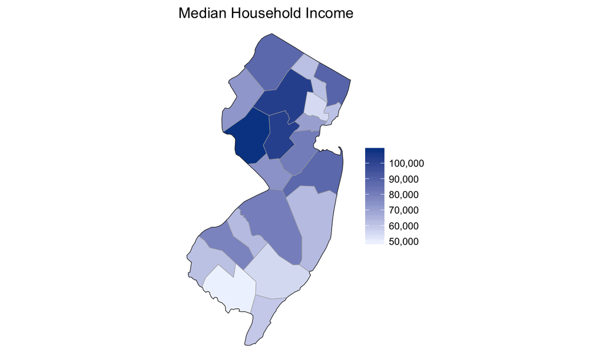

```r
nj_median_household_income %>%
  dplyr::rename(value = estimate) %>%
  mutate(region = as.integer(GEOID)) %>%
  choroplethr::county_choropleth(title = "Median Household Income", num_colors = 1, state_zoom = "new jersey")
```

Not every use of census data has to be a map.

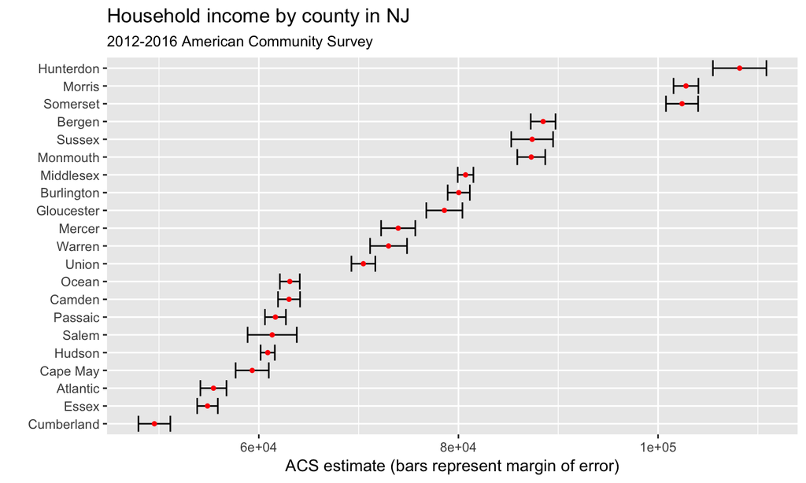

```r
nj_median_household_income %>%
  mutate(NAME = str_replace(NAME, " County, New Jersey", "")) %>%
  mutate(NAME = reorder(NAME, estimate)) %>%
  ggplot(aes(x = estimate, y = NAME)) +
  geom_errorbarh(aes(xmin = estimate - moe, xmax = estimate + moe)) +
  geom_point(color = "red", size = 1) +
  labs(title = "Household income by county in NJ",
       subtitle = "2012-2016 American Community Survey",
       y = "",
       x = "ACS estimate (bars represent margin of error)")
```

- ACS data is reported on finer geographic units than states and counties, known as “tracts”:

```r
## Change geography to "tract"
## and add geometry = TRUE for plotting purposes

nj_median_household_income2 <-
  get_acs(geography = "tract",
              variables = c(medincome = "B19013_001"),
              state = "NJ",
              geometry = TRUE)
```

```
## Please note: `get_acs()` now defaults to a year or endyear of 2016.
```

[output not shown]

```r
glimpse(nj_median_household_income2)
```

```
## Observations: 2,006
## Variables: 6
## $ GEOID    <chr> "34021002701", "34021003500", "34021004407", "3402300...
## $ NAME     <chr> "Census Tract 27.01, Mercer County, New Jersey", "Cen...
## $ variable <chr> "medincome", "medincome", "medincome", "medincome", "...
## $ estimate <dbl> 50168, 56917, 89755, 109643, 60734, 71801, 140250, 94...
## $ moe      <dbl> 10950, 3395, 7329, 19955, 7938, 9265, 22577, 19661, 1...
## $ geometry <S3: sfc_MULTIPOLYGON> MULTIPOLYGON (((-74.73281 4..., MULT...
```

## Plotting census data with `ggplot2`

- The `geometry = TRUE` argument in `get_acs()` downloads polygon information for plotting
- the `geom_sf()` function in `ggplot2` can use that information, but currently only the development version of the `ggplot2` package:

```r
devtools::install_github("tidyverse/ggplot2")
```

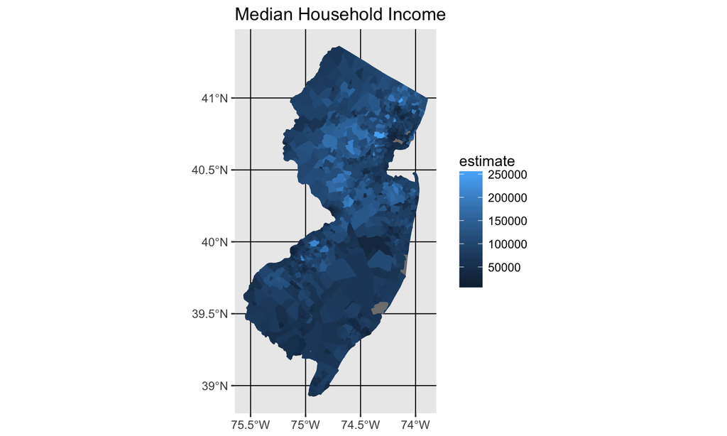

```r
nj_median_household_income2 %>%
  ggplot(aes(fill = estimate, color = estimate)) +
  geom_sf() +
  ggtitle("Median Household Income")
```

```r
middlesex_rental <-
  get_acs(
  geography = "tract",
  variables = c(medrental = "B25064_001"),
  state = "NJ",
  county = "Middlesex",
  geometry = TRUE
  )
```

```
## Please note: `get_acs()` now defaults to a year or endyear of 2016.
```

```r
glimpse(middlesex_rental)
```

```
## Observations: 175
## Variables: 6
## $ GEOID    <chr> "34023000403", "34023001200", "34023001600", "3402300...
## $ NAME     <chr> "Census Tract 4.03, Middlesex County, New Jersey", "C...
## $ variable <chr> "medrental", "medrental", "medrental", "medrental", "...
## $ estimate <dbl> 1848, 1245, 1144, 1551, 1682, 1211, 1492, 1437, 1211,...
## $ moe      <dbl> 161, 86, 116, 240, 803, 133, 149, 39, 218, NA, 150, 8...
## $ geometry <S3: sfc_MULTIPOLYGON> MULTIPOLYGON (((-74.49729 4..., MULT...
```

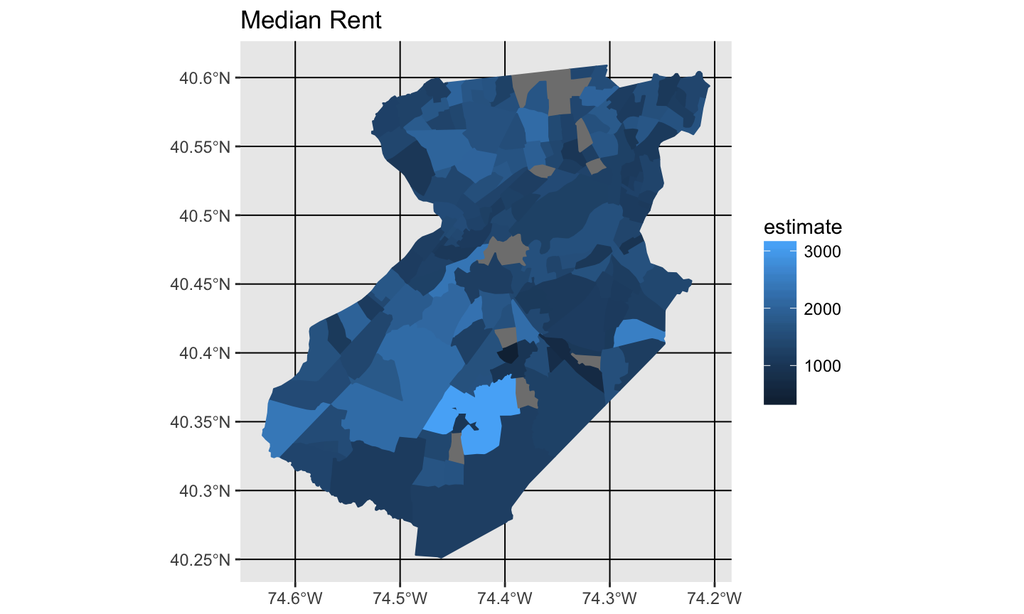

[figure not shown]

```r
middlesex_rental %>%
  ggplot(aes(fill = estimate, color = estimate)) +
  geom_sf() +
  ggtitle("Median Rent")
```

## Leaflet

- Leaflet is a very popular set of Javascript libraries for interactive maps.
- There is a nice R package `leaflet`, to interface with them.
- There are lots of details at https://rstudio.github.io/leaflet/

To quote that webpage, the basic usage is

1. Create a map widget by calling leaflet().
2. Add layers (i.e., features) to the map by using layer functions (e.g. `addTiles`, `addMarkers`, `addPolygons`) to modify the map widget.
3. Repeat step 2 as desired.
4. Print the map widget to display it.

```r
pal <- colorQuantile("Greens", domain = nj_median_household_income2$estimate, n = 9)

nj_median_household_income2 %>%
    st_transform(crs = "+init=epsg:4326") %>%
    leaflet() %>%
    addProviderTiles(provider = "CartoDB.Positron") %>%
    addPolygons(popup = ~ str_extract(NAME, "^([^,]*)"),
                stroke = FALSE,
                smoothFactor = 0,
                fillOpacity = 0.5,
                color = ~ pal(estimate)) %>%
    addLegend("bottomright",
              pal = pal,
              values = ~ estimate,
              title = "Median Household Income",
              opacity = 1)
```

[output not shown]

## In class assignment

- Generate a leaflet interactive map of rent (at the census tract level) in NJ.